# Early Evidence on Generative AI Exposure and Labor Market Outcomes

**Team Members:** Aesha Gandhi, Pinaki Ghosh, Shambhavi Khanna, Isaac Vergara  
**Stakeholder:** Director of Workforce Policy, State Department of Labor  
**Repository:** [GitHub Repository](https://github.com/isaacvm98/UDS/tree/main)

## Stakeholder Summary

This memo is written for a Director of Workforce Policy at a state Department of Labor. The intended stakeholder is assumed to be comfortable interpreting applied research and labor market indicators, but not interested in econometric detail. The main priority is actionable evidence that can inform workforce planning and early-career employment policy.

## Executive Summary

This memo examines whether workers in industries with higher exposure to generative AI experienced different labor market outcomes after the arrival of GenAI tools, and whether those patterns were more pronounced for younger workers. The analysis uses CPS ASEC data from 2016-2025, links those records to an industry-level AI exposure measure (`AIIE`), and compares how employment outcomes changed after the GenAI period began.

The clearest pattern is a modest worsening in unemployment outcomes after 2023 for workers in higher-AI-exposure industries. That shift appears more pronounced for workers ages 25-34 than for older workers. By contrast, no comparable wage effect is visible in the data over this short post period.

These results should be interpreted with caution. The unemployment findings are more informative than the wage findings, but neither result should be treated as definitive proof of causality. Even so, the evidence points to a practical concern for this stakeholder: labor market conditions may be softening somewhat more for younger workers in AI-exposed sectors, which makes those workers an appropriate focus for monitoring and policy attention.

## Decisions To Be Made

Based on these findings, three near-term decisions appear especially relevant:

1. Whether to prioritize monitoring and support for younger workers in AI-exposed sectors, especially workers in the 25-34 range.
2. Whether to expand labor-market monitoring so that hiring, job-finding, and layoffs can be separated more clearly in future work.
3. Whether to treat wage changes as a secondary indicator and focus policy attention first on employment outcomes.

## The Problem

Public debate about generative AI often revolves around questions of job displacement or wage depression by artificial intelligence. From the perspective of a labor market policymaker, however, a more pertinent question might be limited to whether workers in more exposed industries are experiencing worse labor market outcomes, especially among younger workers.

## Analytical Approach

To study this question, CPS ASEC data from 2016-2025 were merged with an industry-level AI exposure measure, `AIIE`. The analysis then compares how unemployment and wage outcomes changed after the GenAI period began in industries with higher AI exposure versus industries with lower AI exposure.

The memo focuses on two outcomes:

- Unemployment
- Wage income

The analysis also looks separately at younger workers ages 25-34 to assess whether labor market changes appear more concentrated earlier in workers' careers.

Examples of relatively high-AI-exposure industries in this sample include legal services, accounting and payroll services, computer systems design, and management consulting. Lower-exposure examples include landscaping, services to buildings and dwellings, warehousing and storage, and truck transportation. These examples are drawn from industries near the top and bottom of the AI exposure distribution in the sample, and are intended to give a concrete sense of what higher- and lower-exposure industries look like in practice.

More emphasis is placed on the unemployment results because they are more consistent with the assumptions needed for this type of comparison. The wage results are still useful descriptively, but they are less persuasive as evidence of a distinct AI-related shift.

## Descriptive Patterns

The descriptive trends help establish the baseline pattern before turning to the main comparisons. The plots below show annual averages with smooth pre- and post-period trend lines and uncertainty bands. High-AI-exposure industries generally have lower unemployment than low-exposure industries throughout the sample, but that gap narrows after the GenAI period begins.

[figure not shown]

*Figure 1. Annual unemployment averages by AI exposure group, with separate pre/post LOWESS fits and 95% confidence bands.*

The age-focused descriptive plots point in the same direction. The relative post-period unemployment shift appears more pronounced for workers ages 25-34 than for workers ages 50-64, although the descriptive evidence alone does not identify the reason for that difference.

[figure not shown]

*Figure 2. Annual unemployment averages for workers ages 25-34, with separate pre/post LOWESS fits and 95% confidence bands.*

[figure not shown]

*Figure 3. Annual unemployment averages for workers ages 50-64, with separate pre/post LOWESS fits and 95% confidence bands.*

The wage plot is included for completeness, but it shows much less visual separation by exposure group after the GenAI period begins.

[figure not shown]

*Figure 4. Annual log wage averages by AI exposure group, with separate pre/post LOWESS fits and 95% confidence bands.*

## Main Findings

### 1. Higher AI exposure is associated with a relative increase in unemployment after 2023

The main unemployment comparison suggests that unemployment outcomes worsened slightly more after 2023 in higher-AI-exposure industries than in lower-exposure industries.

This is a modest effect, not a dramatic one. It also does not mean exposed industries became high-unemployment industries overall. In the raw data, those industries still tend to have lower unemployment than less-exposed industries. The key point is that their advantage narrowed in the post period.

### 2. The unemployment shift is larger for workers ages 25-34

The age comparison suggests that the post-period unemployment shift is larger for workers ages 25-34 than for workers ages 35-64.

That pattern matters because it suggests the labor market impact is not evenly spread across age groups. At the same time, the analysis does not identify the exact mechanism. The safest conclusion is that younger workers in higher-AI-exposure industries experienced relatively weaker unemployment outcomes after 2023.

Notably, the observed gap between the two cohorts is more than just an interesting trend seen in the data; it is sufficiently large to be assured that it is unlikely to occur by chance. The results show that the change in unemployment since 2023 is significantly greater for workers aged 25-34 compared to those aged 35-64, controlling for age and educational attainment by industry.

### 3. The youngest subgroup shows the largest point estimate, but the age split is not conclusive

When the younger group is split further, the estimated effect is larger for ages 25-29 than for ages 30-34. However, that difference is not statistically precise enough to support a strong claim that the youngest subgroup is distinctly more affected.

The age-split evidence is therefore best treated as suggestive. It points toward somewhat greater vulnerability among the youngest workers in the sample, but it does not establish a sharp divide within the 25-34 group.

### 4. No meaningful wage effect is detected

The wage analysis does not show evidence that wages changed differently after 2024 in higher-AI-exposure industries.

This should not be read as proof that AI has no wage effects. The post period is still short, and wage adjustments may take longer to appear. The wage analysis is also the weaker comparison in this memo because its pre-period patterns are less stable.

## Why the Unemployment Result Is More Informative Than the Wage Result

In order to be confident that the post-2023 divergence in unemployment was not merely a result of pre-existing trends, one needs to establish whether there were any signs of growing apart between higher- and lower-AI-exposed industries before the generative AI was popularized. Here, the logic is simple, if the two industries were already diverging before 2023, one cannot confidently claim that their separation is caused by AI. On the other hand, if the two industries were moving alike and only started diverging after 2023, such results are likely caused by AI.

This test proves rather positive for unemployment but not quite for wage. In most years before 2023, higher- and lower-AI-exposure industries behaved almost alike in terms of unemployment. As for wages, higher-AI-exposed industries had been earning more money long before the arrival of generative AI. Thus, in terms of wages, the current results are hardly convincing enough since any increase in wages is hardly attributed to AI but rather to something else. This explains the rationale behind paying more attention to unemployment data rather than wages in this memo.

[figure not shown]

*Figure 5. Year-by-year comparisons of how each outcome is associated with AI exposure, using 2022 as the reference year.*

The robustness check that drops 2020 reaches a similar conclusion. The unemployment pattern remains visible, which reduces concern that the result is being driven entirely by pandemic-era volatility.

[figure not shown]

*Figure 6. The same year-by-year comparison excluding 2020. The broad pattern remains similar.*

## Robustness

At the same time, the broader caution remains the same: these checks improve confidence that the pattern is not a one-year anomaly, but they do not turn the analysis into definitive causal proof.

## Limitations

This analysis has a few important limitations.

First, the CPS is a repeated cross-section, not a panel, so the same worker cannot be followed over time. The results therefore describe changes in group-level outcomes rather than individual trajectories.

Second, `AIIE` measures potential AI exposure based on industry task content, not actual AI adoption by a specific employer.

Third, the data in this case do not differentiate between whether workers were laid off because of involuntary conditions or they chose to leave their employment for whatever reason. Therefore, the results of unemployment may be as a consequence of either hiring being lower or firing being higher, or both.

Fourth, the post period is still short, especially for wages.

Finally, the supporting diagnostic checks are more favorable for unemployment than for wages, but they are not strong enough to remove all concern about pre-existing differences across industries.

## Conclusion

The main takeaway is that labor market conditions appear to have weakened somewhat more after 2023 for younger workers in higher-AI-exposure industries. The unemployment comparison points in that direction, and the age breakdown suggests the pattern is stronger for workers ages 25-34 than for older workers.

That said, the memo should not be read as definitive proof that generative AI caused these changes. The evidence is better viewed as an early warning signal. For this stakeholder, the most practical implication is that younger workers in AI-exposed sectors warrant closer monitoring, while wage effects are not yet clearly visible in the data.

## Technical Appendix

This appendix documents how the dataset was assembled and how the models were estimated. It reproduces the main analytical workflow from:

- `data_merging.ipynb` for dataset construction and crosswalk logic
- `models/causal_analysis.ipynb` for sample creation, weighted descriptive analysis, parallel-trends checks, DiD estimation, and robustness checks

### Appendix A. Data Assembly Code

Below shows how the CPS data were merged with industry-level AI exposure (`AIIE`) and occupation-level AI exposure (`AIOE`). Because CPS ASEC uses three different Census industry vintages across 2016–2025 (2012 codes for 2016–2019, 2017 codes for 2020–2024, 2022 codes for 2025), the assembly builds a single unified AIIE lookup that covers all three vintages via alias rows so every year resolves against the same table.

|  | YEAR | SERIAL | MONTH | CPSID | ASECFLAG | ASECWTH | PERNUM | CPSIDP | CPSIDV | ASECWT | AGE | EMPSTAT | LABFORCE | OCC | IND | EDUC | INCWAGE | IND_2022 | industry_desc | AIIE |
| --- | --- | --- | --- | --- | --- | --- | --- | --- | --- | --- | --- | --- | --- | --- | --- | --- | --- | --- | --- | --- |
| 0 | 2016 | 2 | 3 | 20141202933700 | 1 | 1132.05 | 1 | 20141202933701 | 201412029337011 | 1132.05 | 79 | 36 | 1 | 0 | 0 | 30 | 0 | 0 | NaN | NaN |
| 1 | 2016 | 7 | 3 | 20151202935900 | 1 | 1077.54 | 1 | 20151202935901 | 201512029359011 | 1077.54 | 60 | 32 | 1 | 0 | 0 | 50 | 0 | 0 | NaN | NaN |
| 2 | 2016 | 7 | 3 | 20151202935900 | 1 | 1077.54 | 2 | 20151202935902 | 201512029359021 | 1077.54 | 59 | 32 | 1 | 0 | 0 | 81 | 0 | 0 | NaN | NaN |
| 3 | 2016 | 8 | 3 | 20160202937400 | 1 | 1151.49 | 1 | 20160202937401 | 201602029374011 | 1151.49 | 69 | 36 | 1 | 0 | 0 | 81 | 0 | 0 | NaN | NaN |
| 4 | 2016 | 9 | 3 | 20160102910900 | 1 | 705.00 | 1 | 20160102910901 | 201601029109011 | 705.00 | 24 | 21 | 2 | 9140 | 6190 | 73 | 6000 | 6190 | Taxi and limousine service | 1.369857 |

|  | OCC | occ_desc | AIOE |
| --- | --- | --- | --- |
| 0 | 10 | Chief executives | 1.334246 |
| 1 | 20 | General and operations managers | 0.574877 |
| 2 | 40 | Advertising and promotions managers | 1.294387 |
| 3 | 51 | Marketing managers | 1.315032 |
| 4 | 52 | Sales managers | 1.266280 |

|  | YEAR | SERIAL | MONTH | CPSID | ASECFLAG | ASECWTH | PERNUM | CPSIDP | CPSIDV | ASECWT | ... | LABFORCE | OCC | IND | EDUC | INCWAGE | IND_2022 | industry_desc | AIIE | occ_desc | AIOE |
| --- | --- | --- | --- | --- | --- | --- | --- | --- | --- | --- | --- | --- | --- | --- | --- | --- | --- | --- | --- | --- | --- |
| 0 | 2016 | 2 | 3 | 20141202933700 | 1 | 1132.05 | 1 | 20141202933701 | 201412029337011 | 1132.05 | ... | 1 | 0 | 0 | 30 | 0 | 0 | NaN | NaN | NaN | NaN |
| 1 | 2016 | 7 | 3 | 20151202935900 | 1 | 1077.54 | 1 | 20151202935901 | 201512029359011 | 1077.54 | ... | 1 | 0 | 0 | 50 | 0 | 0 | NaN | NaN | NaN | NaN |
| 2 | 2016 | 7 | 3 | 20151202935900 | 1 | 1077.54 | 2 | 20151202935902 | 201512029359021 | 1077.54 | ... | 1 | 0 | 0 | 81 | 0 | 0 | NaN | NaN | NaN | NaN |
| 3 | 2016 | 8 | 3 | 20160202937400 | 1 | 1151.49 | 1 | 20160202937401 | 201602029374011 | 1151.49 | ... | 1 | 0 | 0 | 81 | 0 | 0 | NaN | NaN | NaN | NaN |
| 4 | 2016 | 9 | 3 | 20160102910900 | 1 | 705.00 | 1 | 20160102910901 | 201601029109011 | 705.00 | ... | 2 | 9140 | 6190 | 73 | 6000 | 6190 | Taxi and limousine service | 1.369857 | NaN | NaN |

5 rows × 22 columns

### Appendix B. Analysis Setup and Variable Construction

The next blocks reproduce the final causal analysis setup, including reproducibility settings, sample restrictions, variable definitions, and helper functions used throughout the analysis.

#### Analysis Frame and Key Variables

The final analysis uses CPS ASEC repeated cross-sections from 2016-2025 merged with industry-level AI exposure, `AIIE`. The analytical frame applies the following restrictions and variable definitions:

- Working-age sample: ages 25-64
- Exposure requirement: non-missing `AIIE`
- Unemployment sample: individuals in the labor force
- Wage sample: employed individuals with positive wage income
- Main wage DiD sample: same as the wage sample, excluding 2023 as a transition year
- Survey weights: `ASECWT`
- Clustered standard errors: by `IND_2022`
- `post_unemployment = 1` for `YEAR >= 2023`
- `post_wage = 1` for `YEAR >= 2024`
- `early_career = 1` for ages 25-34
- `log_wage = log(INCWAGE)` for positive wage observations

For plots only, `AIIE` is also split into low- and high-exposure groups using the 25th and 75th percentiles. The regressions use continuous `AIIE`, not the grouped version.

### Appendix C. Core Estimation Code

This section reproduces the main estimation workflow from the causal analysis notebook. It starts with the model specifications, then shows the sample checks, descriptive plots, event-study diagnostics, main difference-in-differences regressions, and age-heterogeneity specifications.

#### Difference-in-Differences Specifications

The baseline unemployment difference-in-differences model is:

$$ \begin{aligned} unemployed_{it} &= \beta_0 + \beta_1 AIIE_j + \beta_2 post^{unemp}_t \\ &\quad + \beta_3 \left(AIIE_j \times post^{unemp}_t\right) + \beta_4 AGE_i \\ &\quad + \sum_e \delta_e 1\{EDUC_i = e\} + \varepsilon_{it} \end{aligned} $$

The unemployment heterogeneity model adds a triple interaction:

$$ \begin{aligned} unemployed_{it} &= \alpha_0 + \alpha_1 AIIE_j + \alpha_2 post^{unemp}_t + \alpha_3 early\_career_i \\ &\quad + \alpha_4 \left(AIIE_j \times post^{unemp}_t\right) \\ &\quad + \alpha_5 \left(AIIE_j \times early\_career_i\right) \\ &\quad + \alpha_6 \left(post^{unemp}_t \times early\_career_i\right) \\ &\quad + \alpha_7 \left(AIIE_j \times post^{unemp}_t \times early\_career_i\right) \\ &\quad + \alpha_8 AGE_i + \sum_e \rho_e 1\{EDUC_i = e\} + u_{it} \end{aligned} $$

The baseline wage difference-in-differences model is:

$$ \begin{aligned} \log(wage_{it}) &= \gamma_0 + \gamma_1 AIIE_j + \gamma_2 post^{wage}_t \\ &\quad + \gamma_3 \left(AIIE_j \times post^{wage}_t\right) + \gamma_4 AGE_i \\ &\quad + \sum_e \kappa_e 1\{EDUC_i = e\} + \nu_{it} \end{aligned} $$

The wage heterogeneity model parallels the unemployment triple-interaction setup:

$$ \begin{aligned} \log(wage_{it}) &= \eta_0 + \eta_1 AIIE_j + \eta_2 post^{wage}_t + \eta_3 early\_career_i \\ &\quad + \eta_4 \left(AIIE_j \times post^{wage}_t\right) \\ &\quad + \eta_5 \left(AIIE_j \times early\_career_i\right) \\ &\quad + \eta_6 \left(post^{wage}_t \times early\_career_i\right) \\ &\quad + \eta_7 \left(AIIE_j \times post^{wage}_t \times early\_career_i\right) \\ &\quad + \eta_8 AGE_i + \sum_e \phi_e 1\{EDUC_i = e\} + \omega_{it} \end{aligned} $$

Variable definitions:

- $unemployed_{it}$: indicator equal to 1 if individual $i$ is unemployed in year $t$
- $\log(wage_{it})$: log wage income for individual $i$ in year $t$
- $AIIE_j$: AI Industry Exposure for industry $j$
- $post^{unemp}_t$: indicator equal to 1 in 2023-2025
- $post^{wage}_t$: indicator equal to 1 in 2024-2025
- $early\_career_i$: indicator equal to 1 for ages 25-34
- $AGE_i$: age in years
- $1\{EDUC_i = e\}$: education-category controls

All models are estimated using CPS ASEC weights and cluster-robust standard errors at the 2022 Census industry level.

#### Sample Checks and Descriptive Diagnostics

These checks reproduce the summary tables used to verify the analysis samples before estimating the descriptive plots and regressions.

|  | variable | mean | std | min | max | missing |
| --- | --- | --- | --- | --- | --- | --- |
| 0 | AIIE | 0.1365 | 1.1567 | -1.9986 | 2.2156 | 0 |
| 1 | unemployed | 0.0362 | 0.1867 | 0.0000 | 1.0000 | 0 |
| 2 | AGE | 43.1917 | 10.7862 | 25.0000 | 64.0000 | 0 |

|  | variable | mean | std | min | max | missing |
| --- | --- | --- | --- | --- | --- | --- |
| 0 | AIIE | 0.1940 | 1.1496 | -1.9986 | 2.2156 | 0 |
| 1 | INCWAGE | 67,534.2531 | 81,493.3720 | 2.0000 | 2,099,999.0000 | 0 |
| 2 | log_wage | 10.7564 | 0.8956 | 0.6931 | 14.5574 | 0 |
| 3 | AGE | 43.0997 | 10.7663 | 25.0000 | 64.0000 | 0 |

| YEAR | unemployment_sample_n |
| --- | --- |
| 2016 | 63686 |
| 2017 | 64460 |
| 2018 | 62313 |
| 2019 | 63020 |
| 2020 | 54754 |
| 2022 | 52850 |
| 2023 | 50876 |
| 2024 | 50831 |
| 2025 | 50052 |

| YEAR | wage_sample_n |
| --- | --- |
| 2016 | 55908 |
| 2017 | 56881 |
| 2018 | 55256 |
| 2019 | 56276 |
| 2020 | 48316 |
| 2022 | 47023 |
| 2024 | 45466 |
| 2025 | 44847 |

#### Age-Specific Descriptive Plots

The analysis notebook also checks whether the broad unemployment pattern looks similar when focusing on early-career workers and on an older comparison group.

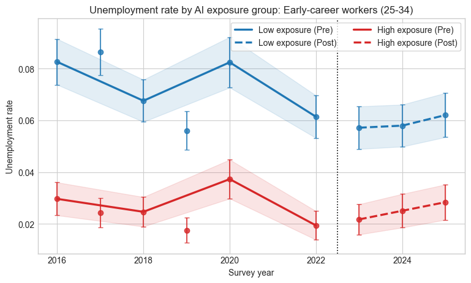

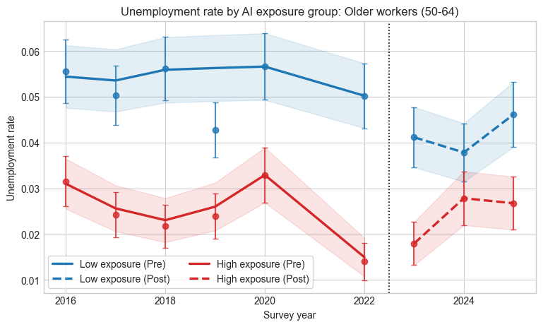

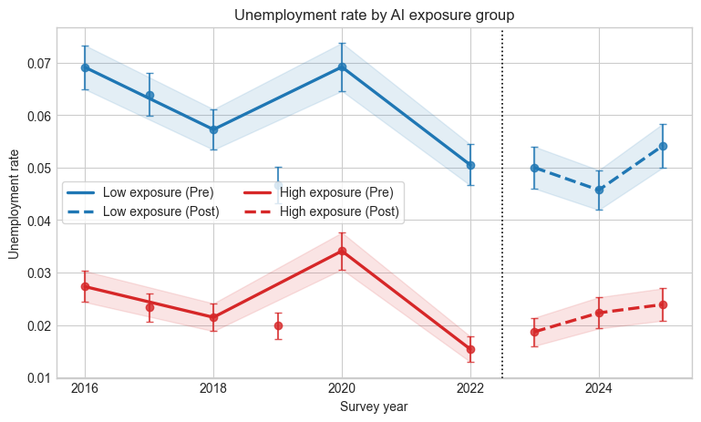

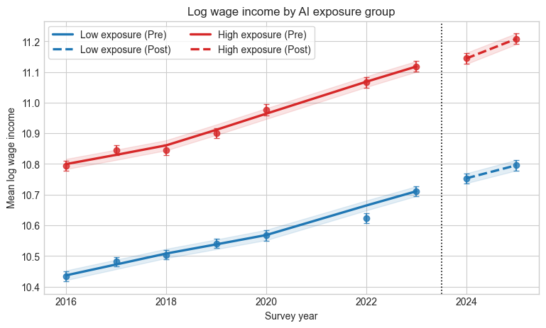

#### Why Check Parallel Trends?

The descriptive figures are useful for showing the broad pattern in the data, but they are not enough on their own to justify a difference-in-differences interpretation. The key identifying assumption behind the DiD design is that, absent the post-2022 expansion of generative AI, outcomes in higher- and lower-exposure industries would have continued to move along similar underlying paths.

This is why we now dive into an event-study version of the model. The event-study check asks whether the relationship between `AIIE` and the outcome was already shifting before the post period began. If those pre-period differences are small, that makes the DiD setup more credible. If they are large or systematic, then the post-period DiD estimates are harder to interpret causally because some of the gap may reflect pre-existing divergence rather than a post-2022 change.

#### Parallel Trends and Event-Study Diagnostic

Parallel trends are evaluated with an event-study specification that replaces the single post-period interaction with year-specific interactions between `AIIE` and survey year:

$$ \begin{aligned} Y_{it} &= \theta_0 + \sum_{\tau \neq 2022} \theta_{\tau} \left(AIIE_j \times 1\{YEAR_t = \tau\}\right) \\ &\quad + \gamma_j + \sum_{\tau \neq 2022} \lambda_{\tau} 1\{YEAR_t = \tau\} \\ &\quad + \sum_k \psi_k X_{kit} + \varepsilon_{it} \end{aligned} $$

where $Y_{it}$ is either unemployment or log wage income, and $X_{kit}$ includes age and education controls. This is not a staggered-adoption design. The omitted year is 2022, so each coefficient shows how the relationship between `AIIE` and the outcome differs relative to 2022.

Interpretation of the diagnostic:

- If pre-period coefficients are close to zero, that supports the parallel-trends assumption.
- If pre-period coefficients are systematically different from zero, that suggests pre-existing differential trends.
- The joint pre-trend test evaluates whether all pre-period `year × AIIE` terms are zero together.

Neither outcome fully passes this diagnostic. The unemployment specification still looks more informative than the wage specification because its pre-period deviations are smaller and less systematic, but it should still be treated as suggestive rather than definitive.

[output not shown]

### Appendix D. Robustness and Heterogeneity Code

The final blocks reproduce two follow-up checks from the analysis notebook: a robustness exercise that excludes 2020 and an age-split specification that asks whether the unemployment effect is more concentrated among workers ages 25-29 than among workers ages 30-34.

|  | coef | std_err | p_value |
| --- | --- | --- | --- |
| AIIE | -0.0058 | 0.0019 | 0.0019 |
| post_unemployment | -0.0022 | 0.0016 | 0.1646 |
| AIIE:post_unemployment | 0.0016 | 0.0013 | 0.2140 |
| early_career | 0.0087 | 0.0015 | 0.0000 |
| AIIE:early_career | -0.0069 | 0.0015 | 0.0000 |
| post_unemployment:early_career | -0.0017 | 0.0017 | 0.2919 |
| AIIE:post_unemployment:early_career | 0.0037 | 0.0014 | 0.0078 |

|  | coef | std_err | p_value |
| --- | --- | --- | --- |
| AIIE | 0.0167 | 0.0465 | 0.7194 |
| post_wage | 0.2346 | 0.0077 | 0.0000 |
| AIIE:post_wage | 0.0012 | 0.0085 | 0.8927 |
| early_career | -0.1817 | 0.0137 | 0.0000 |
| AIIE:early_career | -0.0085 | 0.0194 | 0.6615 |
| post_wage:early_career | 0.0469 | 0.0100 | 0.0000 |
| AIIE:post_wage:early_career | 0.0120 | 0.0083 | 0.1488 |

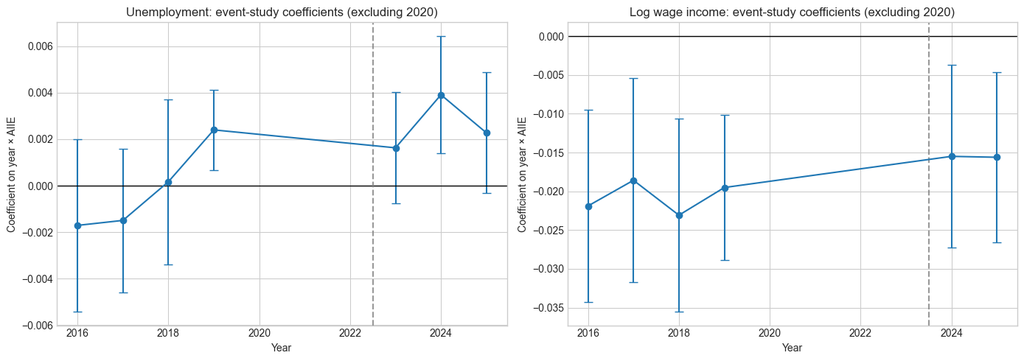

|  | coef | std_err | p_value |
| --- | --- | --- | --- |
| AIIE:post_unemployment:C(age_group, Treatment(reference='35-64'))[T.25-29] | 0.0045 | 0.0020 | 0.0274 |
| AIIE:post_unemployment:C(age_group, Treatment(reference='35-64'))[T.30-34] | 0.0024 | 0.0017 | 0.1712 |

|  | comparison | difference | wald_stat | p_value |
| --- | --- | --- | --- | --- |
| 0 | 25-29 coefficient minus 30-34 coefficient | 0.0022 | 0.6477 | 0.4210 |

#### Interpreting the Age-Heterogeneity Test

This specification separates the younger portion of the sample into workers ages `25-29` and `30-34`, using workers ages `35-64` as the reference group. The interaction coefficients in `age_split_table` show whether the post-2022 unemployment relationship with `AIIE` is larger for each younger subgroup than for the reference group.

The `age_gap_test` output is the key comparison between the two younger subgroups. A positive difference means the `25-29` estimate is larger than the `30-34` estimate. In these results, the point estimate for ages `25-29` is larger, but the formal Wald test indicates that the two subgroup effects are not statistically different from one another. The most careful interpretation is that the unemployment effect appears somewhat stronger for the youngest workers, but the analysis does not provide strong enough evidence to claim that the `25-29` group is affected differently from the `30-34` group in a statistically distinct way.

### Appendix E. Submission Export

The cell below uses `nbconvert` to export the notebook to HTML for submission.

```
Running: /Users/aeshagandhi/Downloads/MIDS-Sp26/UDS/UDS-Project/.venv/bin/python -m jupyter nbconvert --to html --output data_science_memo_submission --log-level=ERROR data_science_memo.ipynb
Created data_science_memo_submission.html
```

```
Running: /Users/aeshagandhi/Downloads/MIDS-Sp26/UDS/UDS-Project/.venv/bin/python -m jupyter nbconvert --to html --output no_code_data_science_memo_submission --no-input --log-level=ERROR data_science_memo.ipynb
Created no_code_data_science_memo_submission.html
```

### Appendix F. Sources

The project draws on the following primary data and reference sources:

Autor, David, Caroline Chin, Anna M. Salomons, and Bryan Seegmiller. *AI, Occupational Exposure, and the Future of Work.* Strategic Management Journal. Accessed through the article appendix and companion materials at `https://sms.onlinelibrary.wiley.com/doi/full/10.1002/smj.3286`.

AIOE Data. *AIOE Data Repository.* GitHub repository. `https://github.com/AIOE-Data`.

Flood, Sarah, Miriam King, Renae Rodgers, Steven Ruggles, and J. Robert Warren. *Integrated Public Use Microdata Series, Current Population Survey: Version 12.0 [dataset].* Minneapolis, MN: IPUMS, 2025. The project uses CPS Annual Social and Economic Supplement (ASEC) files covering survey years 2016-2025.

U.S. Census Bureau. *2022 Census Industry Code List with Crosswalk.* Internal project file: `2022-Census-Industry-Code-List-with-Crosswalk.xlsx`.

U.S. Census Bureau. *2017 Industry Code List with Crosswalk.* Internal project file: `2017-industry-code-list-with-crosswalk.xlsx`.

U.S. Census Bureau. *2018 Occupation Code List and Crosswalk.* Internal project file: `2018-occupation-code-list-and-crosswalk.xlsx`.

For reproducibility within this repository, the main project files are `data_merging.ipynb`, `models/causal_analysis.ipynb`, `reports/data_science_memo.ipynb`, and `notebook_helpers.py`.